# Ford GoBike System

### Investigation Overview

In this investigation, I wanted to look at the factors affecting customer and subscriber riders that could be used to convert customer to subscribers. The main focus was on the four station name, weekday, time duration, rider length, latiude and longitude length and age

### Dataset Overview

This document explores a dataset containing user type, member gender, bike share for all trip and other variables for approximately 184,000 samples. 8,460 data points were removed from the analysis due to inconsistencies or missing information.

### Limitation

- There was no sufficient data such as the actual cost of riders tickets on the bikes.
- Most of the variables in the dataset are string types, which do not allow a high level statistical method to be conducted.
- Their is no enough data to look at the other factor affecting the why riders still remain Subscribers and why csutomer still remain customer riders.
- Insufficient data to look at the other factor affecting Why would customer riders buy annual memberships?

### Riders Weekdays Plot

The plot demonstrates that both customers and subscribers ride bicycles primarily on weekdays, but frequently on Wednesday.

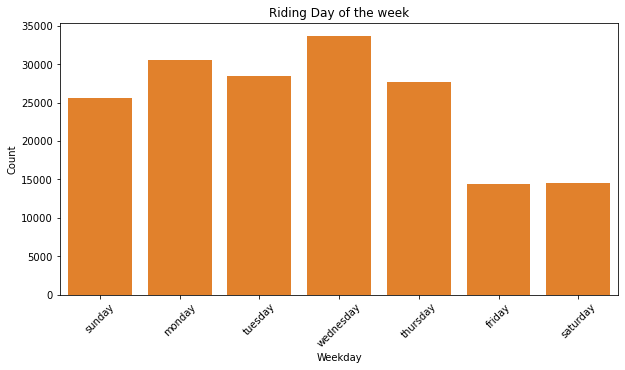

### Age Distribution

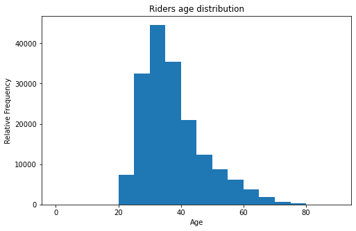

### Station name riders often start their rides

The Embarcadero station has the longest ride duration among the other stations, according to the map. Additionally, Powell Brat and San Francisco stations have longer ride times than other stations.

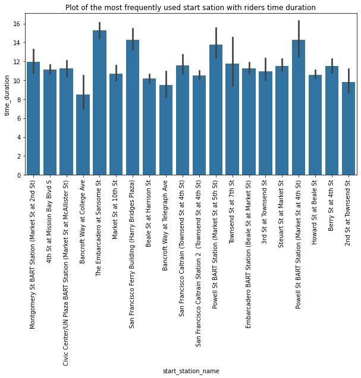

### Days of the week riders mostly use bikes and their time duration

The plot demonstrates that customers ride bikes for a longer period of time than subscribers do On weekends (Saturday and Friday), customers utilize bikes for longer periods of time than subscribers.

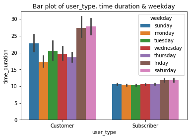

It's interesting to note that while the male gender tends to have a higher average, the male gender with the best features (maximum time duration, user type) also seems to receive the highest riding time duration. Later, it will be worthwhile to look into this further.

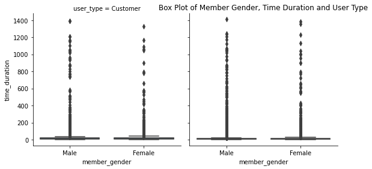